# Oxford 102 Flower Dataset - Deep Learning Classifier Project

#### Created by:Brian Troy (bitroy@yahoo.com) on Nov 3, 2020

## Import Resources

```python
import warnings
warnings.filterwarnings('ignore')
```

```python
# TODO: Make all necessary imports.

%matplotlib inline
%config InlineBackend.figure_format = 'retina'
import time
import json
import pandas as pd
import numpy as np
import matplotlib
import matplotlib.pyplot as plt
import tensorflow as tf
import tensorflow_datasets as tfds
import tensorflow_hub as hub
from tensorflow import keras

from tensorflow.keras import layers
tfds.disable_progress_bar()

from tensorflow.keras.preprocessing.image import ImageDataGenerator

import PIL.Image as Image

import logging
logger = tf.get_logger()
logger.setLevel(logging.ERROR)
```

# Your First AI application

Going forward, AI algorithms will be incorporated into more and more everyday applications. For example, you might want to include an image classifier in a smart phone app. To do this, you'd use a deep learning model trained on hundreds of thousands of images as part of the overall application architecture. A large part of software development in the future will be using these types of models as common parts of applications.

In this project, you'll train an image classifier to recognize different species of flowers. You can imagine using something like this in a phone app that tells you the name of the flower your camera is looking at. In practice you'd train this classifier, then export it for use in your application. We'll be using [this dataset](http://www.robots.ox.ac.uk/~vgg/data/flowers/102/index.html) from Oxford of 102 flower categories, you can see a few examples below.

[figure not shown]

The project is broken down into multiple steps:

- Load the image dataset and create a pipeline.
- Build and Train an image classifier on this dataset.
- Use your trained model to perform inference on flower images.

We'll lead you through each part which you'll implement in Python.

When you've completed this project, you'll have an application that can be trained on any set of labeled images. Here your network will be learning about flowers and end up as a command line application. But, what you do with your new skills depends on your imagination and effort in building a dataset. For example, imagine an app where you take a picture of a car, it tells you what the make and model is, then looks up information about it. Go build your own dataset and make something new.

## Prevent GPU memory choking

```python
gpus = tf.config.experimental.list_physical_devices('GPU')
if gpus:
  try:
    # Currently, memory growth needs to be the same across GPUs
    for gpu in gpus:
      tf.config.experimental.set_memory_growth(gpu, True)
    logical_gpus = tf.config.experimental.list_logical_devices('GPU')
    print(len(gpus), "Physical GPUs,", len(logical_gpus), "Logical GPUs")
  except RuntimeError as e:
    # Memory growth must be set before GPUs have been initialized
    print(e)
```

```
1 Physical GPUs, 1 Logical GPUs
```

```python
print('Using:')
print("\t\u2022 json is: ",json.__version__)
print("\t\u2022 pandas is: ",pd.__version__)
print("\t\u2022 numpy is: ",np.__version__)
print("\t\u2022 matplotlib is: ",matplotlib.__version__)
print("\t\u2022 tensorflow is: ",tf.__version__)
print("\t\u2022 TFDS is: ",tfds.__version__)
print("\t\u2022 tf.hub is: ", hub.__version__)
print("\t\u2022 keras is: ", keras.__version__)
print("\t\u2022 PIL Image is: ",Image.__version__)
print('\t\u2022 Running on GPU' if tf.test.is_gpu_available() else '\t\u2022 GPU device not found. Running on CPU')
```

```
Using:
	• json is:  2.0.9
	• pandas is:  1.1.1
	• numpy is:  1.18.5
	• matplotlib is:  3.1.1
	• tensorflow is:  2.3.1
	• TFDS is:  4.0.1+nightly
	• tf.hub is:  0.9.0
	• keras is:  2.4.0
	• PIL Image is:  7.1.2
	• Running on GPU
```

## Load the Dataset

Here you'll use `tensorflow_datasets` to load the [Oxford Flowers 102 dataset](https://www.tensorflow.org/datasets/catalog/oxford_flowers102). This dataset has 3 splits: `'train'`, `'test'`, and `'validation'`. You'll also need to make sure the training data is normalized and resized to 224x224 pixels as required by the pre-trained networks.

The validation and testing sets are used to measure the model's performance on data it hasn't seen yet, but you'll still need to normalize and resize the images to the appropriate size.

```python
IMG_SIZE = 224

def format_example(image, label):
    image = tf.cast(image, tf.float32)
    # Normalize the pixel values
    image = image / 255.0
    # Resize the image
    image = tf.image.resize(image, (IMG_SIZE, IMG_SIZE))
    return image, label

# TODO: Load the dataset with TensorFlow Datasets.

dataset, dataset_info = tfds.load('oxford_flowers102', as_supervised = True, with_info = True)

# TODO: Create a training set, a validation set and a test set.

raw_training_set, raw_validation_set, raw_test_set = dataset['train'], dataset['validation'], dataset['test']

training_set = raw_training_set.map(format_example)
validation_set = raw_validation_set.map(format_example)
test_set = raw_test_set.map(format_example)
```

[output not shown]

## Explore the Dataset

```python
# TODO: Get the number of examples in each set from the dataset info.

print("\u0332".join('SPLITS:'))
numTrain = dataset_info.splits['train'].num_examples
numValidation = dataset_info.splits['validation'].num_examples
numTest = dataset_info.splits['test'].num_examples

print("There are {} samples in the Training set.\n".format(numTrain))
print("There are {} samples in the Validation set.\n".format(numValidation))
print("There are {} samples in the Test set.\n".format(numTest))

# TODO: Get the number of classes in the dataset from the dataset info.

numClasses = dataset_info.features['label'].num_classes
print("\u0332".join('\nCLASSES:'))
print("There are {} Classes of Flowers in the dataset.\n".format(numClasses))
```

```
S̲P̲L̲I̲T̲S̲:
There are 1020 samples in the Training set.

There are 1020 samples in the Validation set.

There are 6149 samples in the Test set.


̲C̲L̲A̲S̲S̲E̲S̲:
There are 102 Classes of Flowers in the dataset.
```

```python
# TODO: Print the shape and corresponding label of 3 images in the training set.

print("The shapes of three Training Set sample images are:\n")
for image, label in training_set.take(3):
    print(image.shape[0]," pixels in y, by ", image.shape[1], " pixels in x, and ",image.shape[2], 'color levels.')
    print("The Image Label Class Number is: ",label.numpy(),"\n")
```

```
The shapes of three Training Set sample images are:

224  pixels in y, by  224  pixels in x, and  3 color levels.
The Image Label Class Number is:  72

224  pixels in y, by  224  pixels in x, and  3 color levels.
The Image Label Class Number is:  84

224  pixels in y, by  224  pixels in x, and  3 color levels.
The Image Label Class Number is:  70
```

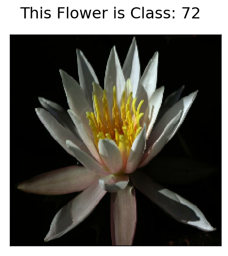

```python
# TODO: Plot 1 image from the training set. Set the title
# of the plot to the corresponding image label.

for image, label in training_set.take(1):
    image = image.numpy()
    label = label.numpy()

plt.imshow(image, cmap= plt.cm.binary)
plt.suptitle("This Flower is Class: " + str(label), fontsize=16)
ax = plt.gca()
ax.axes.xaxis.set_visible(False) #hides axis ticks and labels
ax.axes.yaxis.set_visible(False) #hides axis ticks and labels
plt.show()
```

### Label Mapping

You'll also need to load in a mapping from label to category name. You can find this in the file `label_map.json`. It's a JSON object which you can read in with the [`json` module](https://docs.python.org/3.7/library/json.html). This will give you a dictionary mapping the integer coded labels to the actual names of the flowers.

```python
Dir= '.'
with open(Dir + '\\' + 'label_map.json', 'r') as f:
    class_names = json.load(f)
```

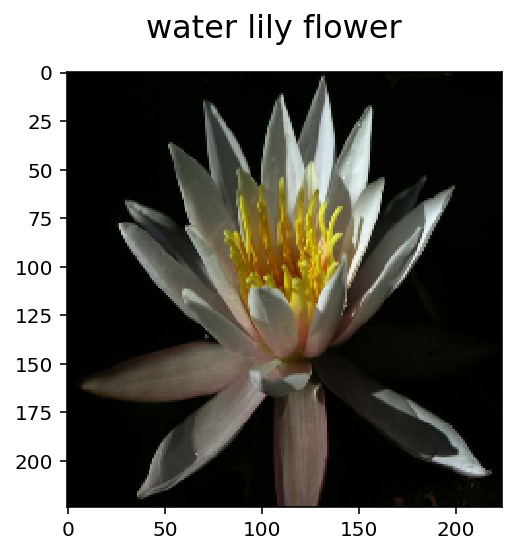

```python
# TODO: Plot 1 image from the training set. Set the title
# of the plot to the corresponding class name.


for image, label in training_set.take(1):
    image = image.numpy()
    label = label.numpy()

plt.imshow(image, cmap= plt.cm.binary)
plt.suptitle(class_names[str(label+1)]+" flower", fontsize=16)
ax = plt.gca()
#ax.axes.xaxis.set_visible(False)
#ax.axes.yaxis.set_visible(False)
plt.show()
```

## Create Pipeline

```python
# TODO: Create a pipeline for each set.

batch_size = 64

training_batches = training_set.shuffle(numTrain//4).batch(batch_size).prefetch(1)
validation_batches = validation_set.batch(batch_size).prefetch(1)
testing_batches = test_set.batch(batch_size).prefetch(1)
```

# Build and Train the Classifier

Now that the data is ready, it's time to build and train the classifier. You should use the MobileNet pre-trained model from TensorFlow Hub to get the image features. Build and train a new feed-forward classifier using those features.

We're going to leave this part up to you. If you want to talk through it with someone, chat with your fellow students!

Refer to the rubric for guidance on successfully completing this section. Things you'll need to do:

- Load the MobileNet pre-trained network from TensorFlow Hub.
- Define a new, untrained feed-forward network as a classifier.
- Train the classifier.
- Plot the loss and accuracy values achieved during training for the training and validation set.
- Save your trained model as a Keras model.

We've left a cell open for you below, but use as many as you need. Our advice is to break the problem up into smaller parts you can run separately. Check that each part is doing what you expect, then move on to the next. You'll likely find that as you work through each part, you'll need to go back and modify your previous code. This is totally normal!

When training make sure you're updating only the weights of the feed-forward network. You should be able to get the validation accuracy above 70% if you build everything right.

**Note for Workspace users:** One important tip if you're using the workspace to run your code: To avoid having your workspace disconnect during the long-running tasks in this notebook, please read in the earlier page in this lesson called Intro to GPU Workspaces about Keeping Your Session Active. You'll want to include code from the workspace_utils.py module. Also, If your model is over 1 GB when saved as a checkpoint, there might be issues with saving backups in your workspace. If your saved checkpoint is larger than 1 GB (you can open a terminal and check with `ls -lh`), you should reduce the size of your hidden layers and train again.

```python
# TODO: Build and train your network.
    ###Load the MobileNet pre-trained network from TensorFlow Hub.

base_model_path ="https://tfhub.dev/google/tf2-preview/mobilenet_v2/classification/4"
base_model = hub.KerasLayer(base_model_path, input_shape=(IMG_SIZE, IMG_SIZE,3))
base_model.trainable = False #Freeze weights of base model.
```

### Note

In this exercise, I utilized multiple concepts learned in the module in addition to transfer learning. Those include Image Augmentation, Additional Layers, Dropout, and Early Stopping. Four (4) models were reated and the overall performance of each was comapared.

```python
EPOCHS = 40
```

### Model 1 - Transfer Learning Model Out of Box

```python
    ###Define a new, untrained feed-forward network as a classifier.
model1 = tf.keras.Sequential([
        base_model,
        tf.keras.layers.Dense(102, activation = 'softmax')
])

model1.summary()
```

```
WARNING: AutoGraph could not transform <bound method KerasLayer.call of <tensorflow_hub.keras_layer.KerasLayer object at 0x000002584B2FBE80>> and will run it as-is.
Please report this to the TensorFlow team. When filing the bug, set the verbosity to 10 (on Linux, `export AUTOGRAPH_VERBOSITY=10`) and attach the full output.
Cause: module 'gast' has no attribute 'Constant'
To silence this warning, decorate the function with @tf.autograph.experimental.do_not_convert
Model: "sequential"
_________________________________________________________________
Layer (type)                 Output Shape              Param #
=================================================================
keras_layer (KerasLayer)     (None, 1001)              3540265
_________________________________________________________________
dense (Dense)                (None, 102)               102204
=================================================================
Total params: 3,642,469
Trainable params: 102,204
Non-trainable params: 3,540,265
_________________________________________________________________
```

```python
    ###Train the classifier.  (should be able to get the validation accuracy above 70%)
    ## Solution
model1.compile(optimizer='adam',
              loss='sparse_categorical_crossentropy',
              metrics=['accuracy'])

history1 = model1.fit(training_batches,
                    epochs=EPOCHS,
                    validation_data=validation_batches)
```

[output not shown]

```python
# TODO: Plot the loss and accuracy values achieved during training for the training and validation set.
    ###Plot the loss and accuracy values achieved during training for the training and validation set.
    ###Save your trained model as a Keras model.
def plotAccLoss(history):
    '''Will take model history as arg & plot accuracy and loss of Test and Val data.'''
    plt.figure(figsize=(15,7))
    plt.plot(history.history['accuracy'])
    plt.plot(history.history['val_accuracy'])
    plt.title('model accuracy')
    plt.ylabel('accuracy')
    plt.xlabel('epoch')
    plt.legend(['train', 'val'], loc='upper left')
    plt.show()

    plt.figure(figsize=(15,7))
    plt.plot(history.history['loss'])
    plt.plot(history.history['val_loss'])
    plt.title('model loss')
    plt.ylabel('loss')
    plt.xlabel('epoch')
    plt.legend(['train', 'val'], loc='upper left')
    plt.show()
```

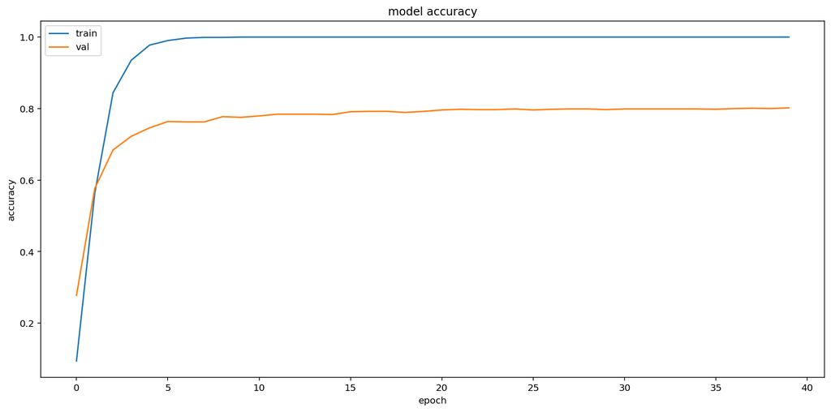

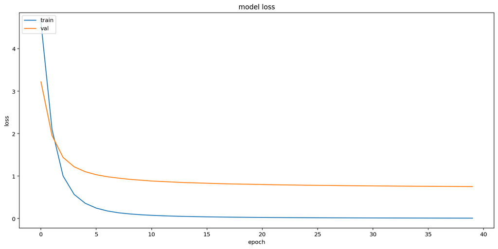

```python
plotAccLoss(history1)
```

### Model 2 - Transfer Learning Model With Image Augmentation

```python
data_augmentation = tf.keras.Sequential([
  layers.experimental.preprocessing.RandomFlip("horizontal_and_vertical"),
  layers.experimental.preprocessing.RandomRotation(0.2),
  layers.experimental.preprocessing.RandomZoom(0.1),
])

input_shape = (224,224,3)

inputs = keras.Input(shape=input_shape)
x = data_augmentation(inputs)

outputs = tf.keras.Sequential([
  base_model,
  tf.keras.layers.Dense(102, activation = 'softmax')
])(x)

model2 = keras.Model(inputs, outputs)
```

```python
    ###Train the classifier.  (should be able to get the validation accuracy above 70%)
    ## Solution
model2.compile(optimizer='adam',
              loss='sparse_categorical_crossentropy',
              metrics=['accuracy'])

history2 = model2.fit(training_batches,
                    epochs=EPOCHS,
                    validation_data=validation_batches)
```

[output not shown]

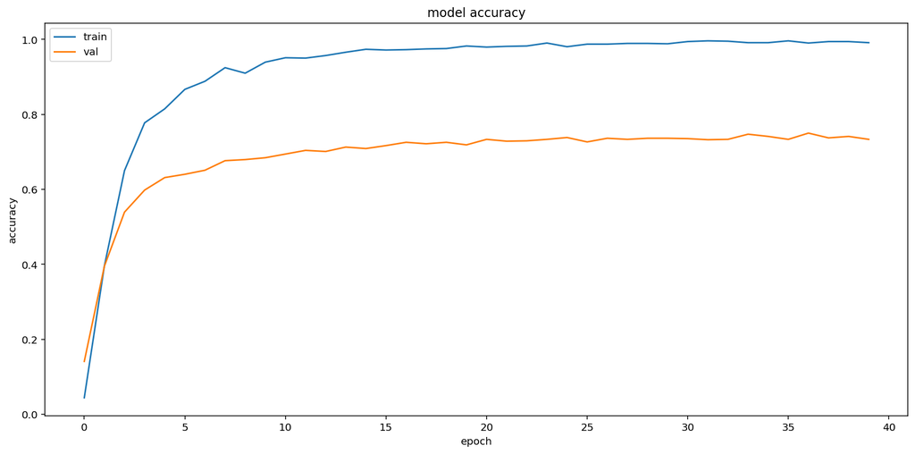

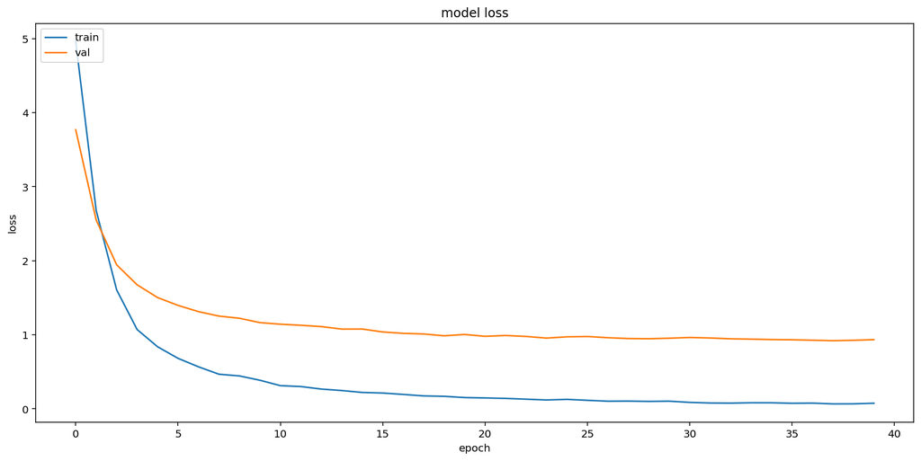

```python
# TODO: Plot the loss and accuracy values achieved during training for the training and validation set.
    ###Plot the loss and accuracy values achieved during training for the training and validation set.
    ###Save your trained model as a Keras model.

plotAccLoss(history2)
```

### Model 3 - Transfer Learning Model With Augmentation And 1 Additional Layer (178 Nodes):

```python
data_augmentation = tf.keras.Sequential([
  layers.experimental.preprocessing.RandomFlip("horizontal_and_vertical"),
  layers.experimental.preprocessing.RandomRotation(0.2),
  layers.experimental.preprocessing.RandomZoom(0.1),
])

input_shape = (224,224,3)

inputs = keras.Input(shape=input_shape)
x = data_augmentation(inputs)

outputs = tf.keras.Sequential([
  base_model,
  tf.keras.layers.Dense(178),
  tf.keras.layers.Dense(102, activation = 'softmax')
])(x)

model3 = keras.Model(inputs, outputs)
```

```python
    ###Train the classifier.  (should be able to get the validation accuracy above 70%)
    ## Solution
model3.compile(optimizer='adam',
              loss='sparse_categorical_crossentropy',
              metrics=['accuracy'])

history3 = model3.fit(training_batches,
                    epochs=EPOCHS,
                    validation_data=validation_batches)
```

[output not shown]

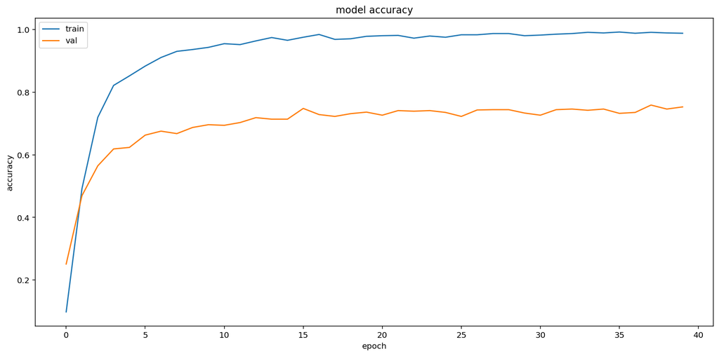

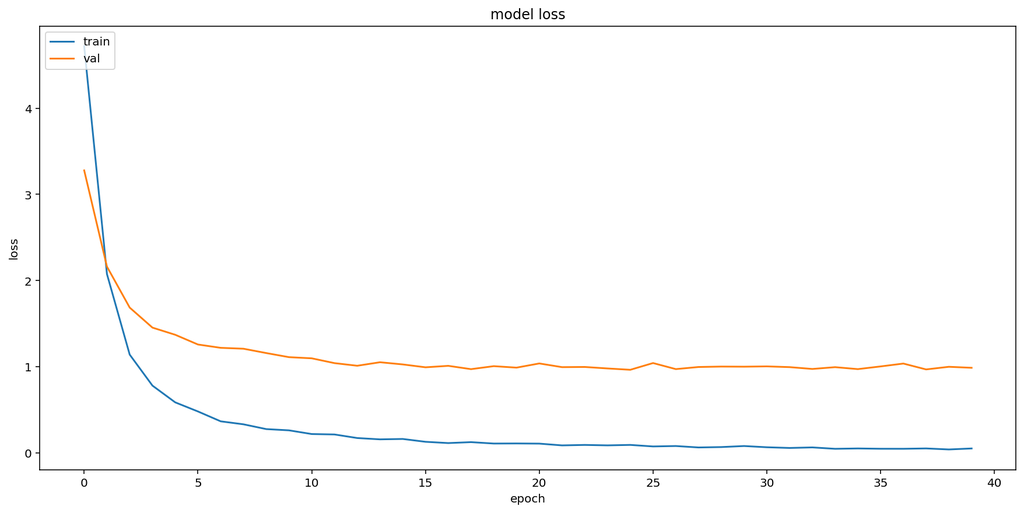

```python
# TODO: Plot the loss and accuracy values achieved during training for the training and validation set.
    ###Plot the loss and accuracy values achieved during training for the training and validation set.
    ###Save your trained model as a Keras model.

plotAccLoss(history3)
```

### Model 4 - Transfer Learning Model With Augmentation, 1 Additional Layer (178 Nodes), Dropout (for overfitting), AND Early Stopping:

```python
data_augmentation = tf.keras.Sequential([
  layers.experimental.preprocessing.RandomFlip("horizontal_and_vertical"),
  layers.experimental.preprocessing.RandomRotation(0.2),
  layers.experimental.preprocessing.RandomZoom(0.1),
])

input_shape = (224,224,3)

inputs = keras.Input(shape=input_shape)
x = data_augmentation(inputs)

outputs = tf.keras.Sequential([
  base_model,
  tf.keras.layers.Dense(178),
  tf.keras.layers.Dropout(0.2),
  tf.keras.layers.Dense(102, activation = 'softmax')
])(x)

model4 = keras.Model(inputs, outputs)
```

```python
    ###Train the classifier.  (should be able to get the validation accuracy above 70%)
    ## Solution
early_stopping = tf.keras.callbacks.EarlyStopping(monitor='val_loss', patience=5)

model4.compile(optimizer='adam',
              loss='sparse_categorical_crossentropy',
              metrics=['accuracy'])

history4 = model4.fit(training_batches,
                    epochs=EPOCHS,
                    validation_data=validation_batches,
                    callbacks=[early_stopping])
```

[output not shown]

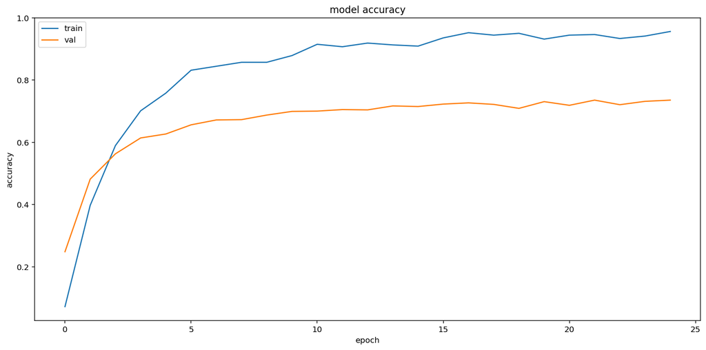

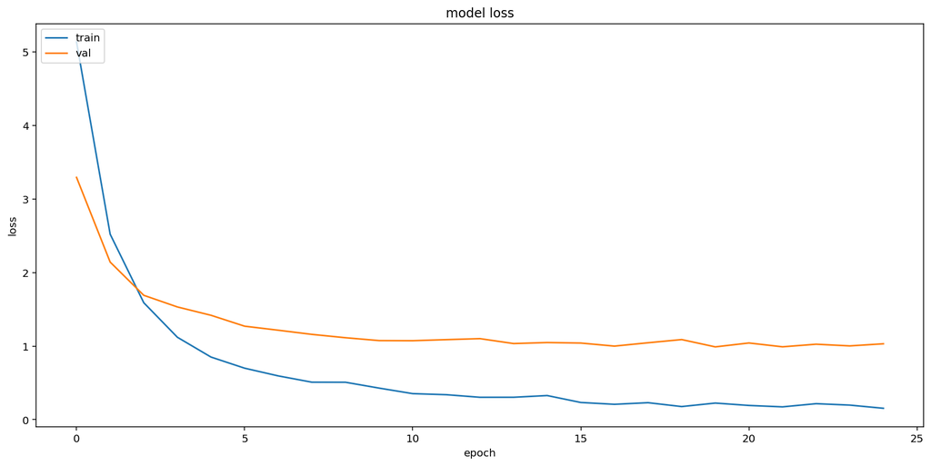

```python
# TODO: Plot the loss and accuracy values achieved during training for the training and validation set.
    ###Plot the loss and accuracy values achieved during training for the training and validation set.
    ###Save your trained model as a Keras model.

plotAccLoss(history4)
```

### Graphical Comparison of 4 Training Approaches (4 models) for Transfer Learning Model With MobileNetV2:

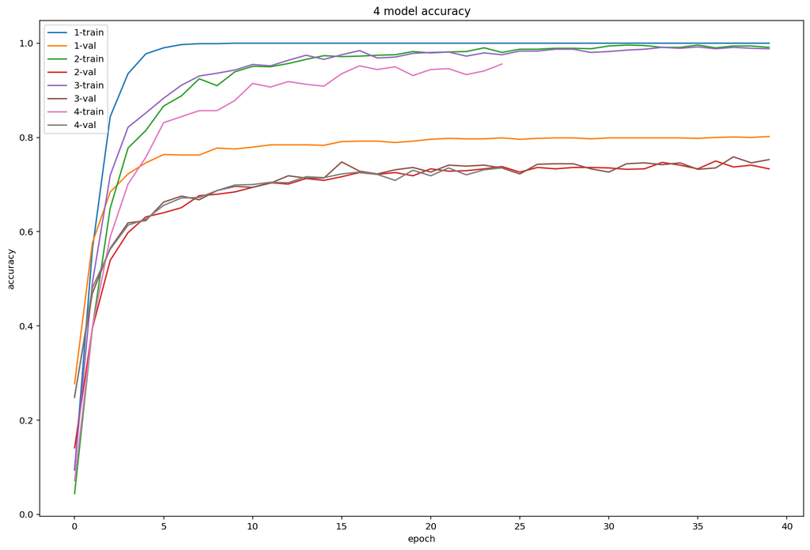

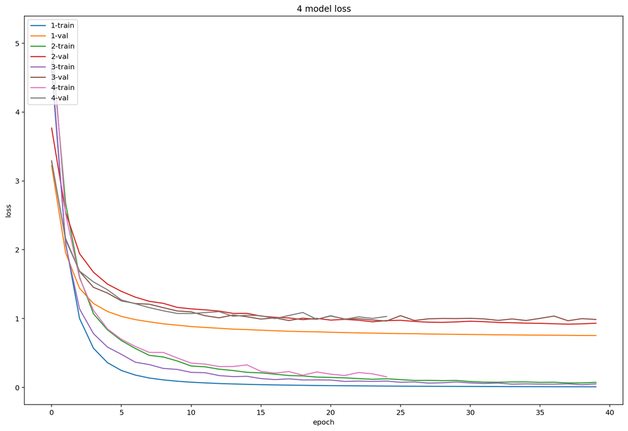

```python
plt.figure(figsize=(15,10))
plt.plot(history1.history['accuracy'])
plt.plot(history1.history['val_accuracy'])
plt.plot(history2.history['accuracy'])
plt.plot(history2.history['val_accuracy'])
plt.plot(history3.history['accuracy'])
plt.plot(history3.history['val_accuracy'])
plt.plot(history4.history['accuracy'])
plt.plot(history4.history['val_accuracy'])
plt.title('4 model accuracy')
plt.ylabel('accuracy')
plt.xlabel('epoch')
plt.legend(['1-train', '1-val','2-train', '2-val','3-train', '3-val','4-train', '4-val'], loc='upper left')
plt.show()

plt.figure(figsize=(15,10))
plt.plot(history1.history['loss'])
plt.plot(history1.history['val_loss'])
plt.plot(history2.history['loss'])
plt.plot(history2.history['val_loss'])
plt.plot(history3.history['loss'])
plt.plot(history3.history['val_loss'])
plt.plot(history4.history['loss'])
plt.plot(history4.history['val_loss'])
plt.title('4 model loss')
plt.ylabel('loss')
plt.xlabel('epoch')
plt.legend(['1-train', '1-val','2-train', '2-val','3-train', '3-val','4-train', '4-val'], loc='upper left')
plt.show()
```

### Training Experiment Conclusion

The four Transfer Learning Classifiers Trained were:

```
- Out of box MobileNetV2
- MobileNetV2 with Image Augmentation
- MobileNetV2 with Image Augmentation, and an extra layer (178 Neurons)
- MobileNetB2 with Image Augmentation, an extra layer (178 Neurons), and 20% Dropout on that layer.
```

The overall **performace prize** for **validation set** data goes to the Model 1 (Out of Box MobileNetV2) transfer learning classifier.

## Testing your Network

It's good practice to test your trained network on test data, images the network has never seen either in training or validation. This will give you a good estimate for the model's performance on completely new images. You should be able to reach around 70% accuracy on the test set if the model has been trained well.

```python
loss1, accuracy1 = model1.evaluate(testing_batches)
loss2, accuracy2 = model2.evaluate(testing_batches)
loss3, accuracy3 = model3.evaluate(testing_batches)
loss4, accuracy4 = model4.evaluate(testing_batches)

df = pd.DataFrame([[loss1,accuracy1],[loss2,accuracy2],[loss3,accuracy3],[loss4,accuracy4]],columns=['Test Loss','Test Accuracy'])
df.head(4)
```

|  | Test Loss | Test Accuracy |
| --- | --- | --- |
| 0 | 0.898748 | 0.768418 |
| 1 | 1.055294 | 0.721581 |
| 2 | 1.189591 | 0.721906 |
| 3 | 1.217119 | 0.699789 |

## Save the Model

Now that your network is trained, save the model so you can load it later for making inference. In the cell below save your model as a Keras model (*i.e.* save it as an HDF5 file).

```python
# TODO: Save your trained model as a Keras model.

t = time.time()

saved_keras_model_filepath = '.\\tfModels\\image_classifier_{}.h5'.format(int(t))

#Note: Only saving model 1 as it gives the best performance
model1.save(saved_keras_model_filepath)
```

## Load the Keras Model

Load the Keras model you saved above.

```python
# TODO: Load the Keras model
reloaded_keras_model = tf.keras.models.load_model(saved_keras_model_filepath,custom_objects={'KerasLayer':hub.KerasLayer})

reloaded_keras_model.summary()
```

```
Model: "sequential"
_________________________________________________________________
Layer (type)                 Output Shape              Param #
=================================================================
keras_layer (KerasLayer)     (None, 1001)              3540265
_________________________________________________________________
dense (Dense)                (None, 102)               102204
=================================================================
Total params: 3,642,469
Trainable params: 102,204
Non-trainable params: 3,540,265
_________________________________________________________________
```

# Inference for Classification

Now you'll write a function that uses your trained network for inference. Write a function called `predict` that takes an image, a model, and then returns the top $K$ most likely class labels along with the probabilities. The function call should look like:

```
probs, classes = predict(image_path, model, top_k)
```

If `top_k=5` the output of the `predict` function should be something like this:

```
probs, classes = predict(image_path, model, 5)
print(probs)
print(classes)
> [ 0.01558163  0.01541934  0.01452626  0.01443549  0.01407339]
> ['70', '3', '45', '62', '55']
```

Your `predict` function should use `PIL` to load the image from the given `image_path`. You can use the Image.open function to load the images. The `Image.open()` function returns an `Image` object. You can convert this `Image` object to a NumPy array by using the `np.asarray()` function.

The `predict` function will also need to handle pre-processing the input image such that it can be used by your model. We recommend you write a separate function called `process_image` that performs the pre-processing. You can then call the `process_image` function from the `predict` function.

### Image Pre-processing

The `process_image` function should take in an image (in the form of a NumPy array) and return an image in the form of a NumPy array with shape `(224, 224, 3)`.

First, you should convert your image into a TensorFlow Tensor and then resize it to the appropriate size using `tf.image.resize`.

Second, the pixel values of the input images are typically encoded as integers in the range 0-255, but the model expects the pixel values to be floats in the range 0-1. Therefore, you'll also need to normalize the pixel values.

Finally, convert your image back to a NumPy array using the `.numpy()` method.

```python
# TODO: Create the process_image function

def process_image(IMG_OBJ):
    '''takes a numpy array image object, casts values to float,
    normalizes to 256 GL, resizes x,y to 224 and returns
    the processed image object'''
    IMG_OBJ = tf.cast(IMG_OBJ, tf.float32)
    IMG_OBJ /= 255
    IMG_OBJ = tf.image.resize(IMG_OBJ, (224, 224))
    IMG_OBJ = IMG_OBJ.numpy()
    return IMG_OBJ
```

To check your `process_image` function we have provided 4 images in the `./test_images/` folder:

- cautleya_spicata.jpg
- hard-leaved_pocket_orchid.jpg
- orange_dahlia.jpg
- wild_pansy.jpg

The code below loads one of the above images using `PIL` and plots the original image alongside the image produced by your `process_image` function. If your `process_image` function works, the plotted image should be the correct size.

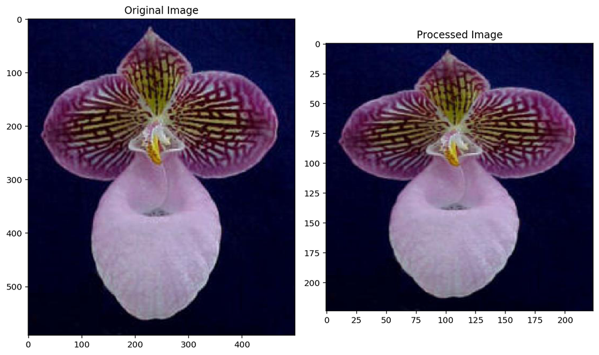

```python
from PIL import Image

image_path = './test_images/hard-leaved_pocket_orchid.jpg'
im = Image.open(image_path)
test_image = np.asarray(im)

processed_test_image = process_image(test_image)

fig, (ax1, ax2) = plt.subplots(figsize=(10,10), ncols=2)
ax1.imshow(test_image)
ax1.set_title('Original Image')
ax2.imshow(processed_test_image)
ax2.set_title('Processed Image')
plt.tight_layout()
plt.show()
```

Once you can get images in the correct format, it's time to write the `predict` function for making inference with your model.

### Inference

Remember, the `predict` function should take an image, a model, and then returns the top $K$ most likely class labels along with the probabilities. The function call should look like:

```
probs, classes = predict(image_path, model, top_k)
```

If `top_k=5` the output of the `predict` function should be something like this:

```
probs, classes = predict(image_path, model, 5)
print(probs)
print(classes)
> [ 0.01558163  0.01541934  0.01452626  0.01443549  0.01407339]
> ['70', '3', '45', '62', '55']
```

Your `predict` function should use `PIL` to load the image from the given `image_path`. You can use the Image.open function to load the images. The `Image.open()` function returns an `Image` object. You can convert this `Image` object to a NumPy array by using the `np.asarray()` function.

**Note:** The image returned by the `process_image` function is a NumPy array with shape `(224, 224, 3)` but the model expects the input images to be of shape `(1, 224, 224, 3)`. This extra dimension represents the batch size. We suggest you use the `np.expand_dims()` function to add the extra dimension.

## Note

**There's a bug** with Reloaded Keras Models Autograph (https://github.com/tensorflow/tensorflow/issues/37144) which **throws the warning**:

"WARNING: AutoGraph could not transform <function Model.make_predict_function..predict_function at 0x0000026D40AC18C8> and will run it as-is. Please report this to the TensorFlow team. When filing the bug, set the verbosity to 10 (on Linux, `export AUTOGRAPH_VERBOSITY=10`) and attach the full output. Cause: 'arguments' object has no attribute 'posonlyargs' To silence this warning, decorate the function with @tf.autograph.experimental.do_not_convert"

It **does not materially affect the classifier inference**, but is an eyesore. A work around would be to use the presaved model, but per project rubrick, the reloaded model will be used with the warning.

```python
# TODO: Create the predict function

def predict(image_path, model, top_k):
    '''takes an image, a model, and then returns
    the top 𝐾 most likely class labels along with
    the probabilities'''
    im = Image.open(image_path)
    im = np.asarray(im)
    im = process_image(im)
    myPred = model.predict(np.expand_dims(im,axis=0))
    s =np.copy(myPred)
    s = -np.sort(-s)
    probs = [s.take(i) for i in range(top_k)]
    labels = [np.argsort(-myPred)[0][i] for i in range(top_k)]
    return probs, labels
```

# Sanity Check

It's always good to check the predictions made by your model to make sure they are correct. To check your predictions we have provided 4 images in the `./test_images/` folder:

- cautleya_spicata.jpg
- hard-leaved_pocket_orchid.jpg
- orange_dahlia.jpg
- wild_pansy.jpg

In the cell below use `matplotlib` to plot the input image alongside the probabilities for the top 5 classes predicted by your model. Plot the probabilities as a bar graph. The plot should look like this:

[figure not shown]

You can convert from the class integer labels to actual flower names using `class_names`.

### Function to plot flower image and assicated label/probability chart

```python
def result(image_path,class_names):
    '''Packages up the flower image,
    and bar chart of prediction
    probabilities and labels'''

    im = Image.open(image_path)
    im = np.asarray(im)
    im1 = process_image(im)
    probs, classes = predict(image_path, reloaded_keras_model, 5)
    labels = [class_names[str(i+1)] for i in classes]
    print("\nTop k probabilities are: ",probs)
    print("Associated classes are: ", classes)
    print("Assciated labels are: ", labels)

    fig, (ax1, ax2) = plt.subplots(figsize=(8,16), ncols=2)
    ax1.imshow(im1, cmap = plt.cm.binary)
    ax1.axis('off')
    #ax1.set_title(class_names[first_label])
    ax2.barh(labels, probs)
    ax2.set_aspect(.2)
    ax2.set_yticks(np.arange(5))
    #ax2.set_yticklabels(class_names, size='small');
    ax2.set_title('Class Probability')
    ax2.set_xlim(0, 1.1)
    plt.tight_layout()
```

### Flower #1

```
WARNING: AutoGraph could not transform <function Model.make_predict_function.<locals>.predict_function at 0x0000025887C52BF8> and will run it as-is.
Please report this to the TensorFlow team. When filing the bug, set the verbosity to 10 (on Linux, `export AUTOGRAPH_VERBOSITY=10`) and attach the full output.
Cause: 'arguments' object has no attribute 'posonlyargs'
To silence this warning, decorate the function with @tf.autograph.experimental.do_not_convert

Top k probabilities are:  [0.98633415, 0.005135969, 0.0035075205, 0.0009377346, 0.0008887307]
Associated classes are:  [60, 23, 45, 10, 38]
Assciated labels are:  ['cautleya spicata', 'red ginger', 'wallflower', 'snapdragon', 'siam tulip']
```

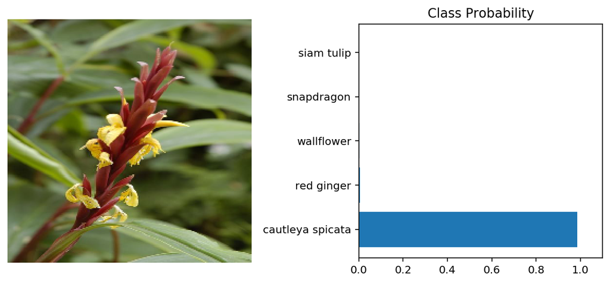

```python
  result('./test_images/cautleya_spicata.jpg',class_names)
```

### Flower #2

```
Top k probabilities are:  [0.9986254, 0.00019590768, 0.00017751321, 0.00015508529, 8.611389e-05]
Associated classes are:  [1, 47, 76, 79, 90]
Assciated labels are:  ['hard-leaved pocket orchid', 'buttercup', 'passion flower', 'anthurium', 'hippeastrum']
```

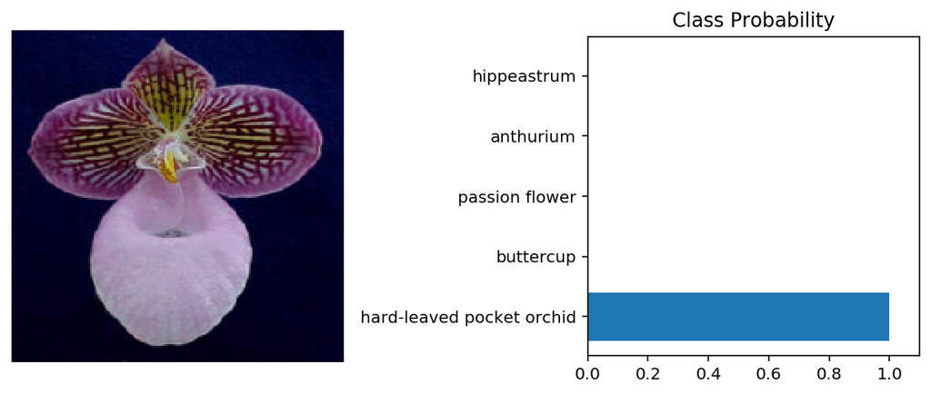

```python
  result('./test_images/hard-leaved_pocket_orchid.jpg',class_names)
```

### Flower #3

```
Top k probabilities are:  [0.44806746, 0.37255758, 0.05751361, 0.030640809, 0.020203933]
Associated classes are:  [4, 58, 65, 55, 99]
Assciated labels are:  ['english marigold', 'orange dahlia', 'osteospermum', 'bishop of llandaff', 'blanket flower']
```

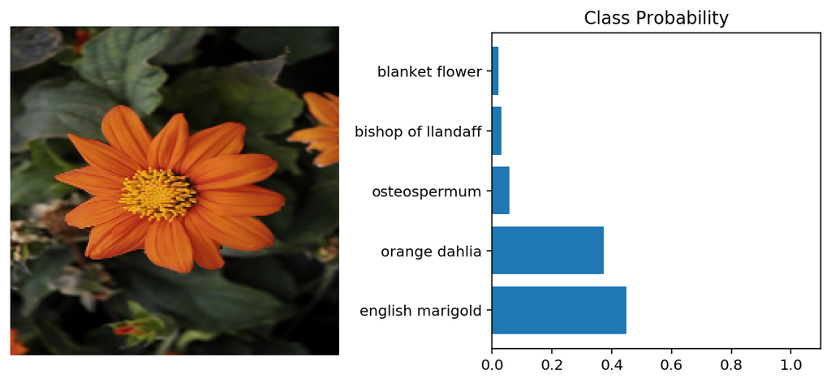

```python
  result('./test_images/orange_dahlia.jpg',class_names)
```

### Flower #4

```
Top k probabilities are:  [0.99939334, 0.000118970755, 9.541398e-05, 7.673108e-05, 7.059252e-05]
Associated classes are:  [51, 63, 18, 33, 47]
Assciated labels are:  ['wild pansy', 'silverbush', 'balloon flower', 'mexican aster', 'buttercup']
```

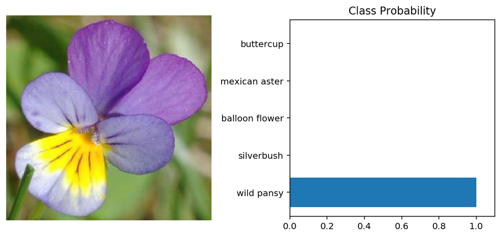

```python
  result('./test_images/wild_pansy.jpg',class_names)
```